# 新冠感染数和各项指标的关系

Kang

5/16/2022

## 概述

统计分析政策强度和各月份新冠感染数对公民科学各项指标的影响。 前者是自上而下的影响，后者是自下而上的影响。 其中，政策强度计划用每个月的紧急事态天数表示。 注意：新冠的实际感染数也受到检测数量和上报数量影响，但是因为我们的研究考虑的是这方面信息如何影响人们出行行为，因此这并不构成问题。 此外，可能会觉得奇怪为什么用的是各县的感染人数，而不是用各城市的感染人数。原因一方面和生态学中的尺度效应有关，另一方面和数据的可获得性有关：人们感知到的、通常能够查到的就是县一级的感染人数，因此其行为应该更多是受到该级感染人数的影响。

## 政策的影响

收集了各地紧急事态期间的数据后，统计了各地各月份的紧急事态天数，发现无法做统计分析，因为紧急事态仅限于四月份和五月份，没有连续的数据可供分析（其他月份紧急事态天数都是0）。 当然，我们可以做可视化，看看这两个月是否表现出某些特征。

本研究指标包括：

总量指标： obs：观测数； obs_id: 鉴定用户数大于0的观测数； idpa：鉴定者数； users：活跃用户数； act_days：活跃天数。

一阶强度指标： obs_per_user：人均观测数； actdays_per_user：人均活跃天数。

二阶强度指标： obs_pu_pd：人均每活跃天内观测数。

其他： id_rate：观测的鉴定率。

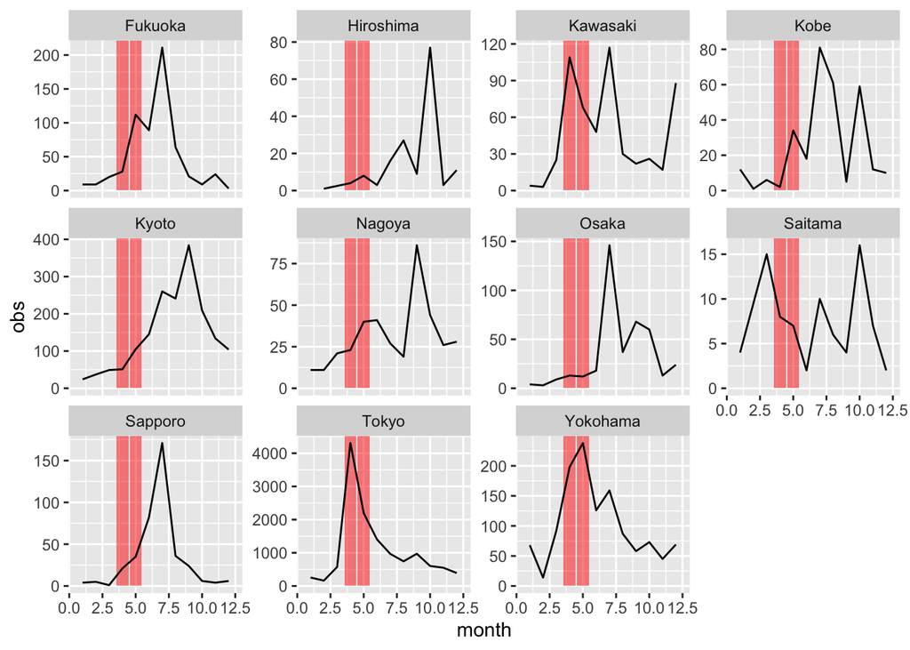

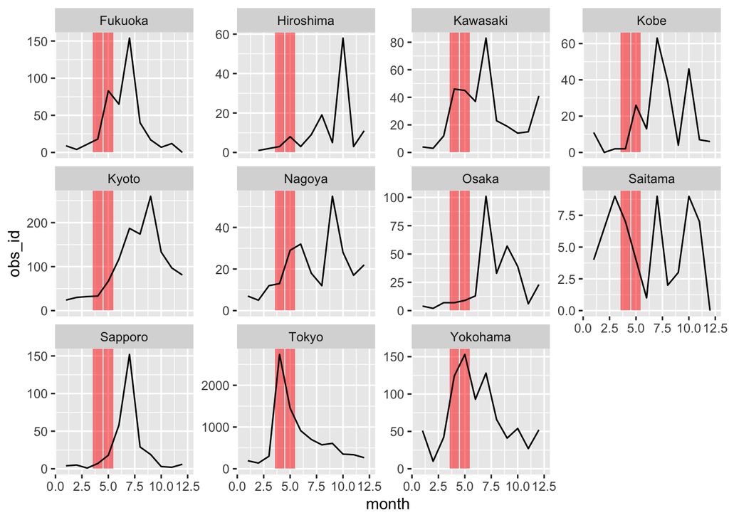

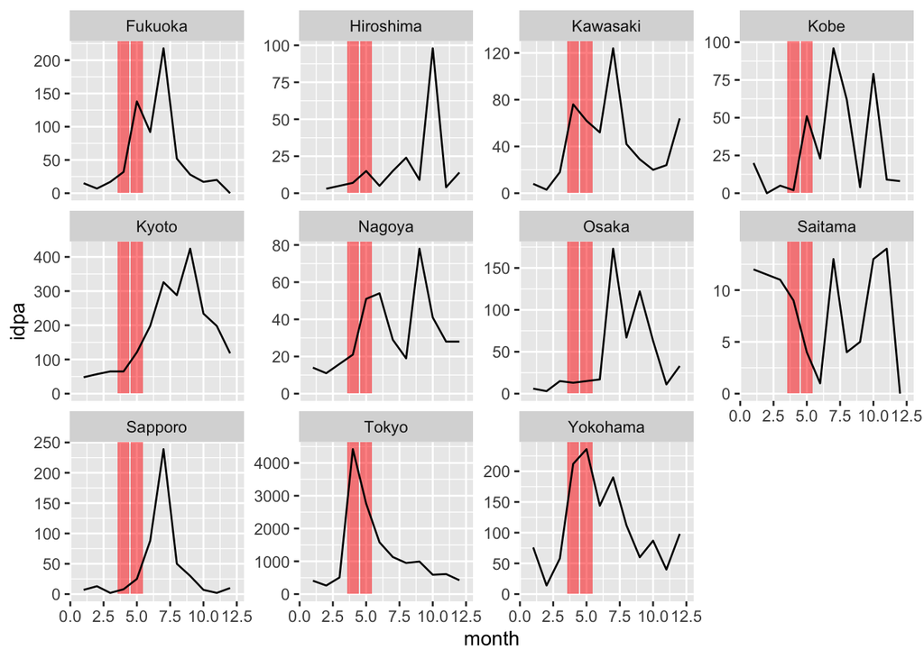

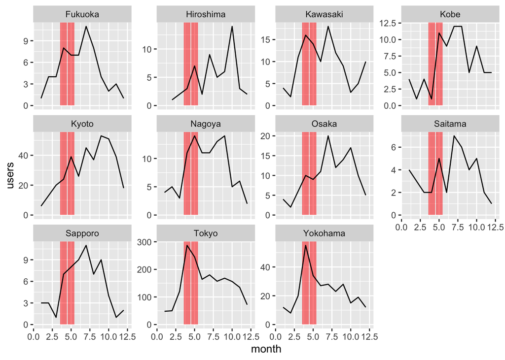

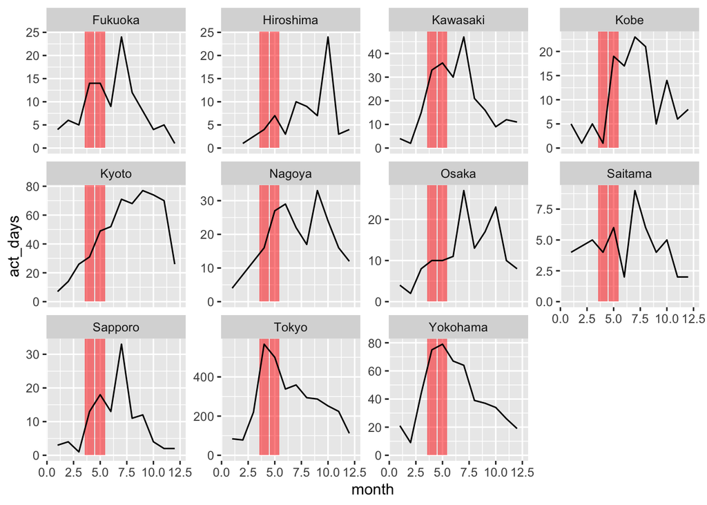

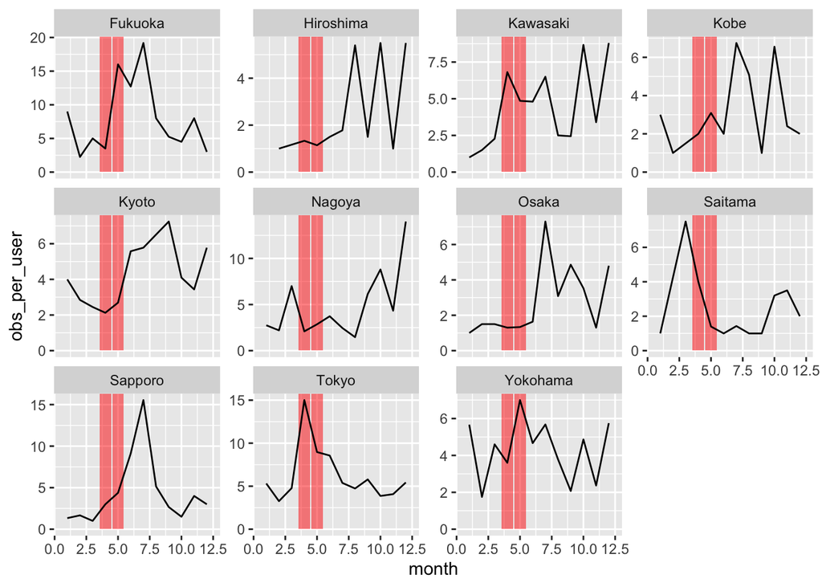

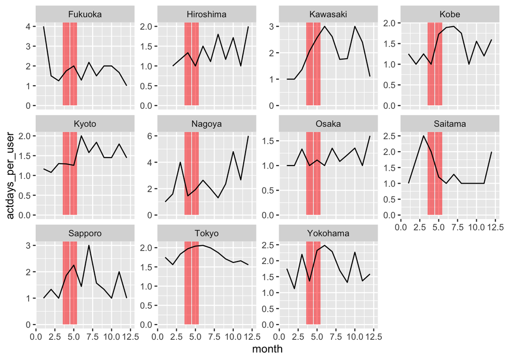

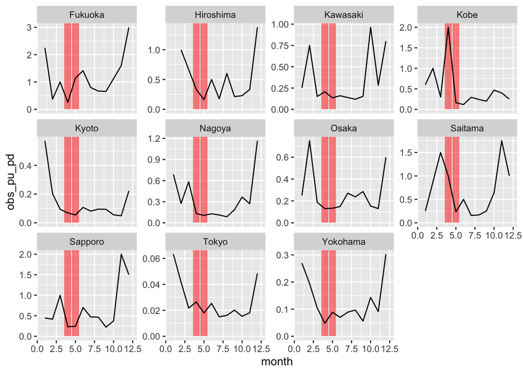

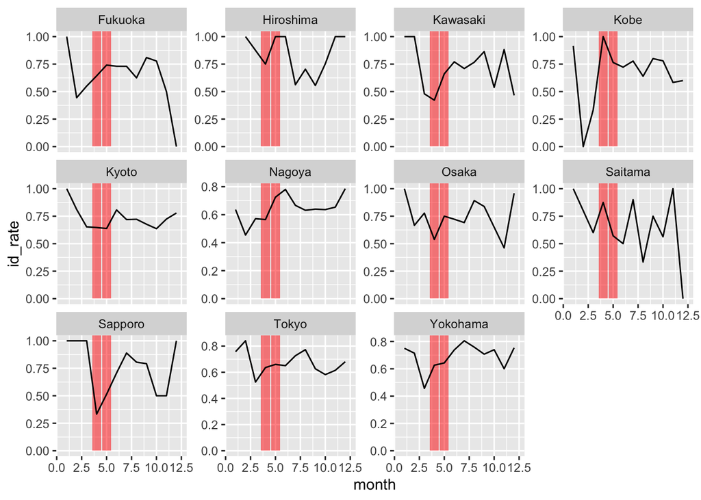

```r
for (i in c("obs", "obs_id", "idpa", "users", "act_days", "obs_per_user",
            "actdays_per_user", "obs_pu_pd", "id_rate")) {
  print(ggplot(emer.citisci) +
    geom_col(aes(x = month, y = ifelse(is.na(prd), 0, Inf)),
             fill = "red", alpha = 0.5) +
    geom_line(aes_string("month", i)) +
    facet_wrap(.~ city, scales = "free_y") +
    labs(y = i))
}
```

## 感染数的影响

首先使用使用原始的绝对值进行分析。 先混合各城市数据进行分析。 当然，由于各城市的人口数不同，这样做对于总量指标显然不合理，但是先看看状况再说。 作图查看各个指标和对应县感染数的关系如下图。横轴是感染数，纵轴是各个指标。

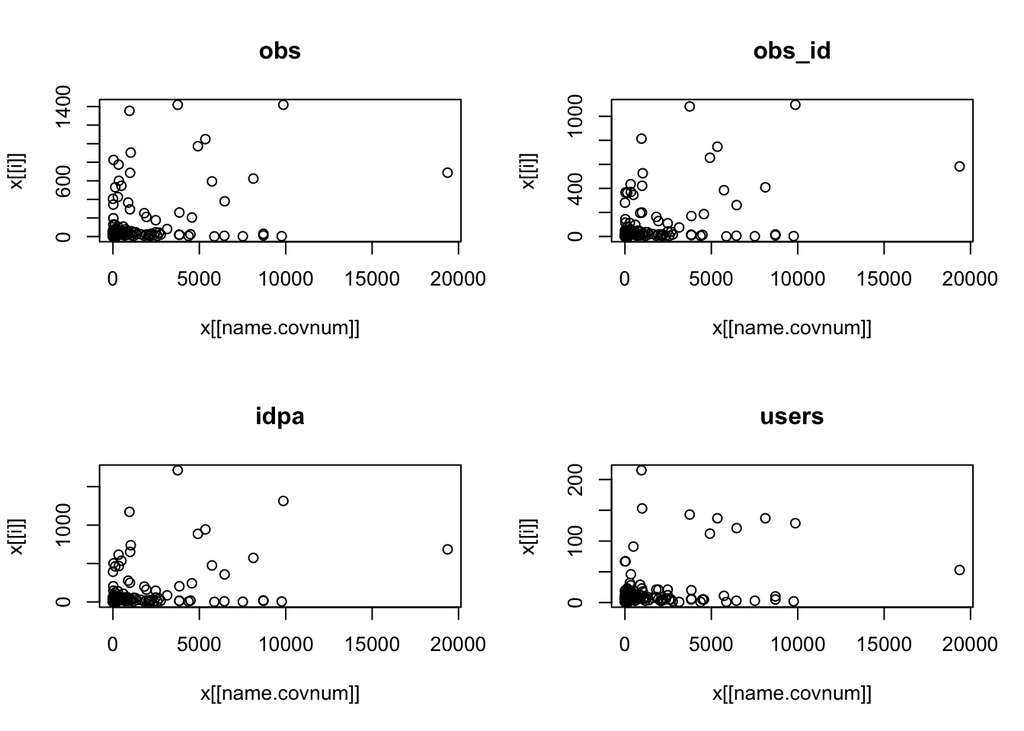

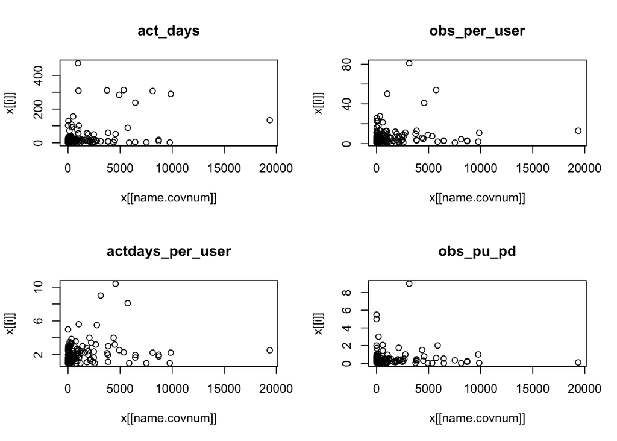

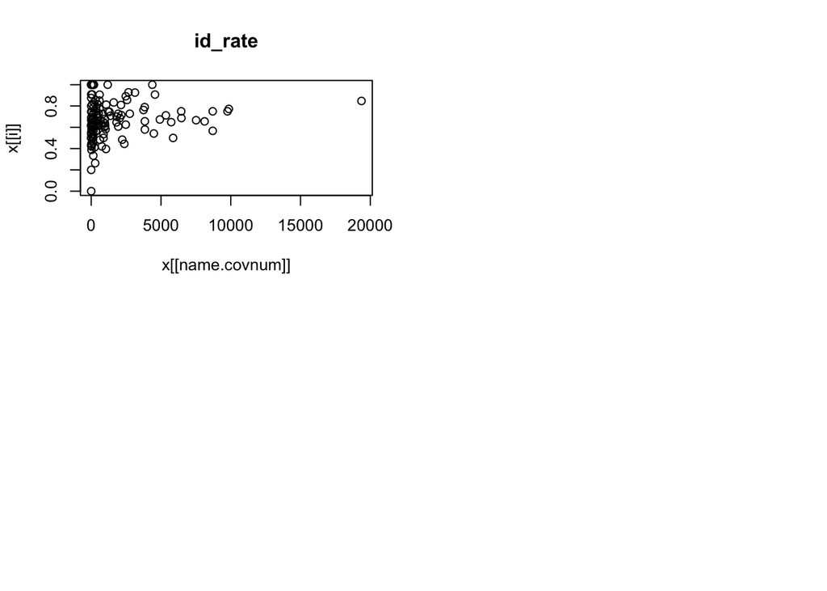

```r
PlotCovnumMet(covid.citisci)
```

```r
CorCovnumMet(covid.citisci)
```

```
## # A tibble: 9 × 5
##   variable         correlation          p p_mark result
##   <chr>                  <dbl>      <dbl> <chr>  <chr>
## 1 obs                   0.327  0.000154   "***"  0.33***
## 2 obs_id                0.394  0.00000387 "***"  0.39***
## 3 idpa                  0.352  0.0000425  "***"  0.35***
## 4 users                 0.291  0.000804   "***"  0.29***
## 5 act_days              0.331  0.000128   "***"  0.33***
## 6 obs_per_user          0.111  0.212      ""     0.11
## 7 actdays_per_user      0.155  0.0792     ""     0.16
## 8 obs_pu_pd            -0.0293 0.742      ""     -0.03
## 9 id_rate               0.162  0.0663     ""     0.16
```

基本结论：

可见大部分数值都集中在较低的范围内，难以看出有什么关联。 统计结果虽然表现出一定的显著相关性，但从分析过程上说，这个分析过程并不合理，很有可能是过拟合而导致了显著性；而且这些结果的相关系数都非常微弱，可见效用并不大。

再来看看标准化之后，分析的结果会是什么样。 对各城市新冠感染人数和各指标进行极值标准化，也就是对每个城市的各个数值做如下处理： 标准化数值 = (原数值-最小值)/(最大值-最小值) 这样所有数值就都落在0-1范围内，消除了城市间由于人口基数等造成的差异。 当然这里标准化也有个问题需要讨论一下：对总量指标进行标准化是没问题的，但是对强度指标（如每用户观测数）进行标准化是否合理？

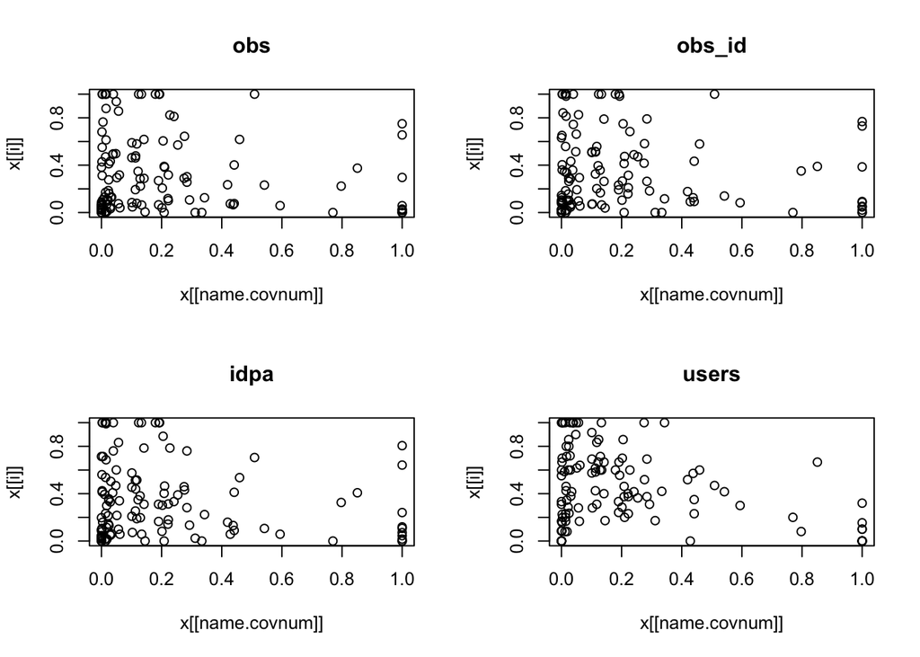

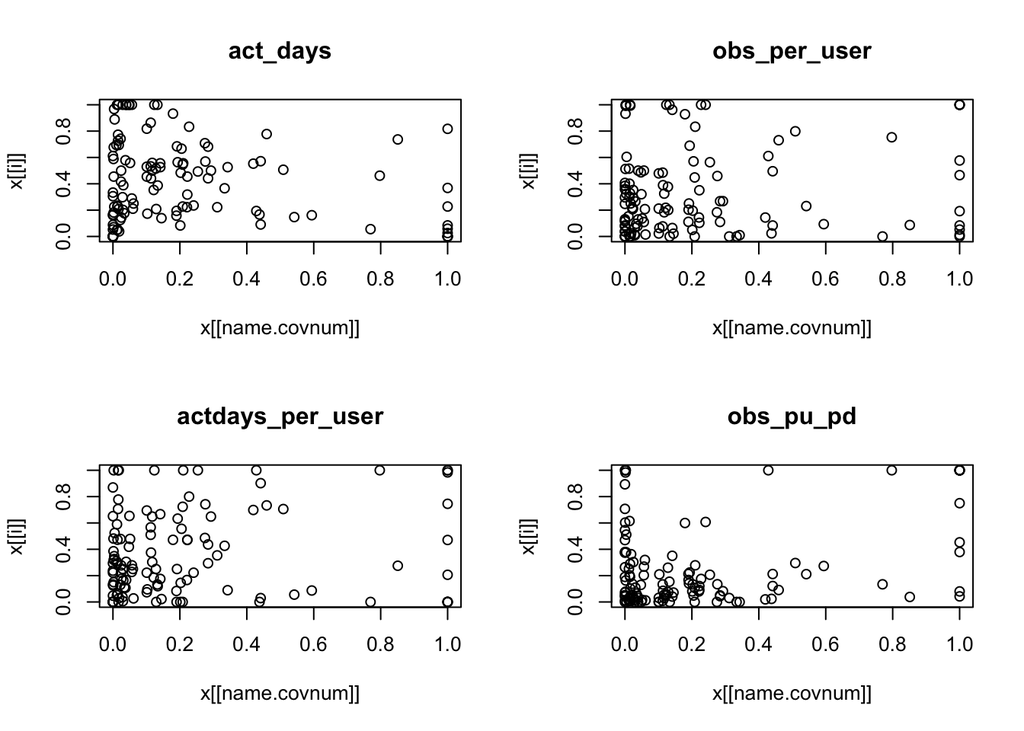

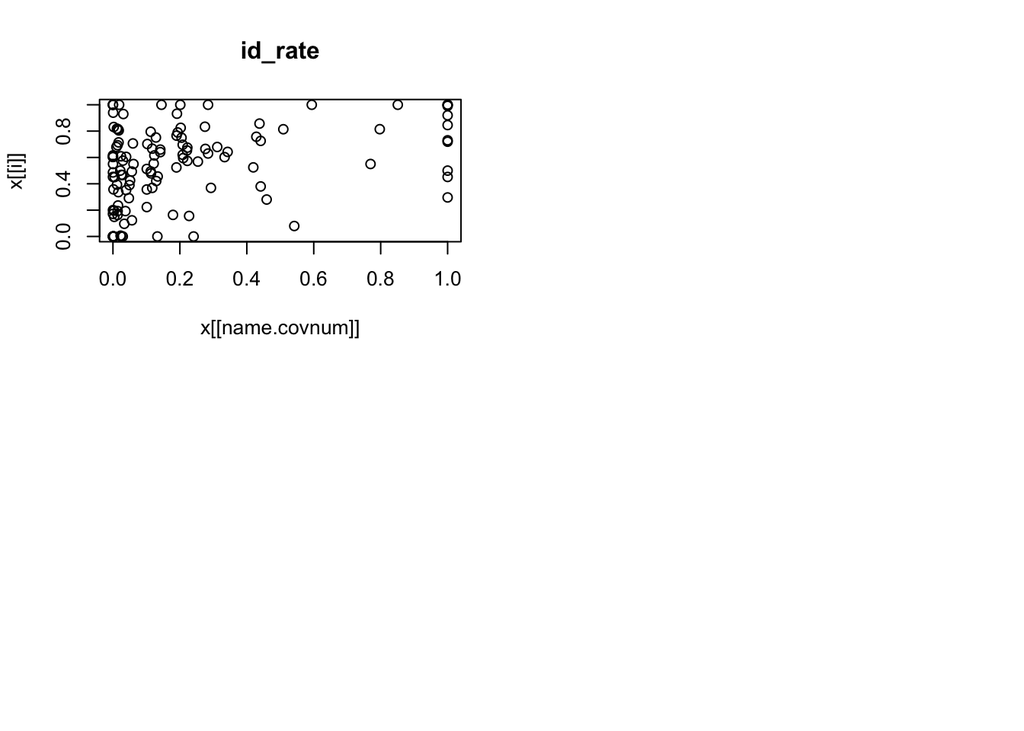

```r
PlotCovnumMet(covid.citisci.scale)
```

```r
CorCovnumMet(covid.citisci.scale)
```

```
## # A tibble: 9 × 5
##   variable         correlation        p p_mark result
##   <chr>                  <dbl>    <dbl> <chr>  <chr>
## 1 obs                  -0.120  0.190    ""     -0.12
## 2 obs_id               -0.102  0.266    ""     -0.1
## 3 idpa                 -0.134  0.145    ""     -0.13
## 4 users                -0.332  0.000209 "***"  -0.33***
## 5 act_days             -0.195  0.0329   "*"    -0.19*
## 6 obs_per_user          0.0922 0.317    ""     0.09
## 7 actdays_per_user      0.156  0.0893   ""     0.16
## 8 obs_pu_pd             0.341  0.000140 "***"  0.34***
## 9 id_rate               0.326  0.000277 "***"  0.33***
```